# Dissertation: Disaggregate analyses for P2->RT

Hannah

8/15/2019

## 1. Dissaggregate analyses predicting RT from P2 amplitude

The P2.meancent.scale variable was standardized by subject and electrode (i.e., centered around the subject/electrode mean and then scaled to have a standard deviation of 1).

DV is trial level RT. Incorrect trials and trials with +/- 75 uV artifacts are excluded. Subjects with < 50% trials accepted are excluded (subs 36, 52, and 69). Sub 60 doesn’t have data for gender task

P2.submean = subject mean (separate subject mean for each electrode)  
P2.meancent.scale = trial level P2 amplitude centered around subject/electrode mean

Included n = 65

### A. Race categorization task

#### A1. Disaggregate within and between subject effects:

Between-subjects effect: **P2.submean**  
Within-subjects effect: **P2.meancent.scale**

```
## lmer(formula = RT ~ P2.submean + P2.meancent.scale + (1 | Subject),
##     data = racedat)
```

```
##  Groups   Name        Std.Dev.
##  Subject  (Intercept) 37.292
##  Residual             82.113
```

|  | Estimate | Std. Error | df | t value | Pr(>\|t\|) |
| --- | --- | --- | --- | --- | --- |
| (Intercept) | 437.524 | 4.685 | 66.53 | 93.393 | 0.000 |
| P2.submean | -0.032 | 0.273 | 34384.53 | -0.116 | 0.908 |
| P2.meancent.scale | -1.535 | 0.325 | 63989.72 | -4.725 | 0.000 |

**With effect-coded predictors included:**

```
## lmer(formula = RT ~ P2.submean + P2.meancent.scale * Race.e *
##     Gen.e + (1 | Subject), data = racedat)
```

```
##  Groups   Name        Std.Dev.
##  Subject  (Intercept) 37.321
##  Residual             81.265
```

|  | Estimate | Std. Error | df | t value | Pr(>\|t\|) |
| --- | --- | --- | --- | --- | --- |
| (Intercept) | 437.573 | 4.687 | 66.476 | 93.358 | 0.000 |
| P2.submean | -0.031 | 0.270 | 35091.076 | -0.115 | 0.909 |
| P2.meancent.scale | -1.327 | 0.322 | 63983.623 | -4.128 | 0.000 |
| Race.e | 9.512 | 0.322 | 63981.246 | 29.582 | 0.000 |
| Gen.e | -3.804 | 0.321 | 63980.800 | -11.833 | 0.000 |
| P2.meancent.scale:Race.e | -0.750 | 0.322 | 63985.386 | -2.331 | 0.020 |
| P2.meancent.scale:Gen.e | -0.458 | 0.322 | 63985.654 | -1.422 | 0.155 |
| Race.e:Gen.e | 5.455 | 0.321 | 63980.857 | 16.966 | 0.000 |
| P2.meancent.scale:Race.e:Gen.e | 1.436 | 0.321 | 63983.315 | 4.467 | 0.000 |

The within-subject effect for Black trials is -0.53. The within-subject effect for White trials is -2.15.

The within-subject effect for Female trials is -0.94. The within-subject effect for Male trials is -1.98.

#### A2. Test within-subject relationship by trial type

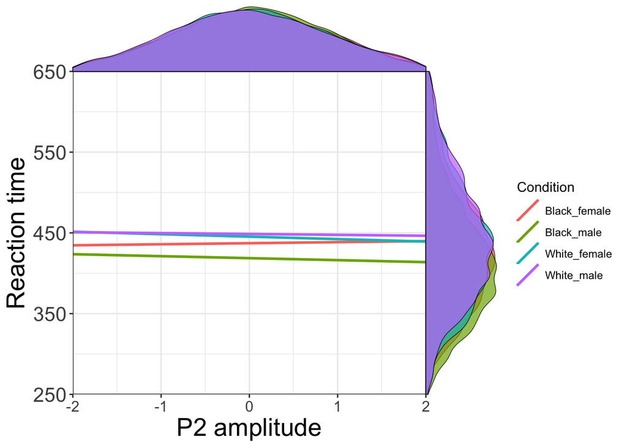

| Target_Race | Target_Gender | Intercept | Slope | Lower_95%CI | Upper_95%CI |
| --- | --- | --- | --- | --- | --- |
| Black | female | 437 | 1.32 | 0.05 | 2.59 |
| Black | male | 419 | -2.47 | -3.77 | -1.17 |
| White | female | 445 | -3.06 | -4.35 | -1.76 |
| White | male | 449 | -1.10 | -2.39 | 0.19 |

**Zoomed in:**

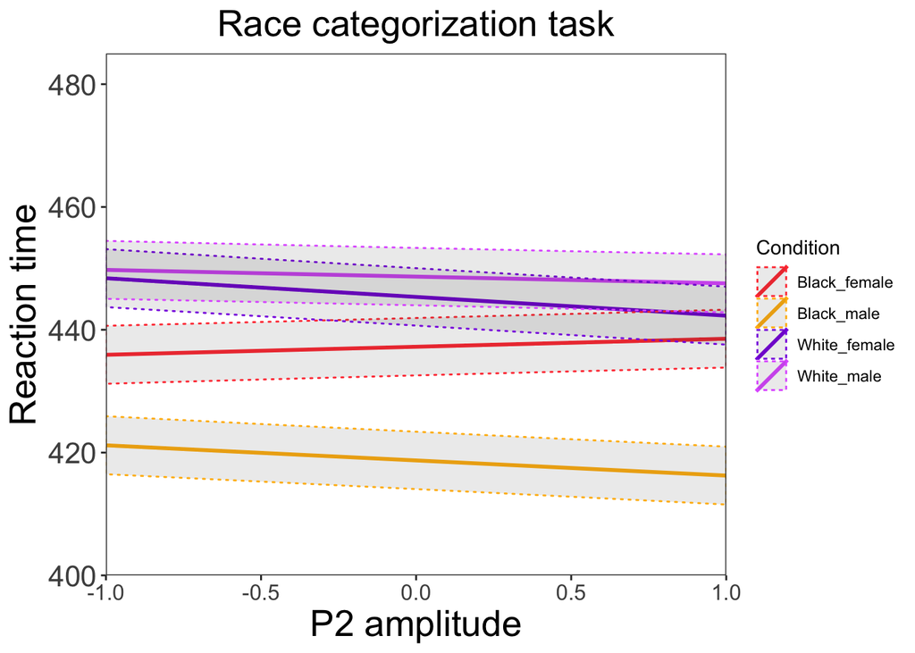

### B. Gender categorization task

#### B1. Disaggregate within and between subject effects:

Between-subjects effect: **P2.submean**  
Within-subjects effect: **P2.meancent.scale**

```
## lmer(formula = RT ~ P2.submean + P2.meancent.scale + (1 | Subject),
##     data = gendat)
```

```
##  Groups   Name        Std.Dev.
##  Subject  (Intercept) 45.698
##  Residual             84.371
```

|  | Estimate | Std. Error | df | t value | Pr(>\|t\|) |
| --- | --- | --- | --- | --- | --- |
| (Intercept) | 450.319 | 5.765 | 64.803 | 78.114 | 0.000 |
| P2.submean | -0.002 | 0.286 | 42574.153 | -0.006 | 0.995 |
| P2.meancent.scale | -1.414 | 0.343 | 61244.761 | -4.125 | 0.000 |

**With effect-coded predictors included:**

```
## lmer(formula = RT ~ P2.submean + P2.meancent.scale * Race.e *
##     Gen.e + (1 | Subject), data = gendat)
```

```
##  Groups   Name        Std.Dev.
##  Subject  (Intercept) 45.683
##  Residual             84.263
```

|  | Estimate | Std. Error | df | t value | Pr(>\|t\|) |
| --- | --- | --- | --- | --- | --- |
| (Intercept) | 450.408 | 5.763 | 64.80 | 78.155 | 0.000 |
| P2.submean | 0.007 | 0.286 | 42621.86 | 0.024 | 0.981 |
| P2.meancent.scale | -1.386 | 0.343 | 61238.76 | -4.043 | 0.000 |
| Race.e | 1.780 | 0.341 | 61236.72 | 5.222 | 0.000 |
| Gen.e | 1.732 | 0.341 | 61236.92 | 5.079 | 0.000 |
| P2.meancent.scale:Race.e | 1.478 | 0.343 | 61238.70 | 4.313 | 0.000 |
| P2.meancent.scale:Gen.e | -0.236 | 0.343 | 61239.70 | -0.687 | 0.492 |
| Race.e:Gen.e | 2.742 | 0.341 | 61237.17 | 8.040 | 0.000 |
| P2.meancent.scale:Race.e:Gen.e | -1.665 | 0.343 | 61239.21 | -4.858 | 0.000 |

The within-subject effect for Black trials is -3.02. The within-subject effect for White trials is 0.17.

The within-subject effect for Female trials is -1.31. The within-subject effect for Male trials is -1.88.

#### B2. Test within-subject relationship by trial type

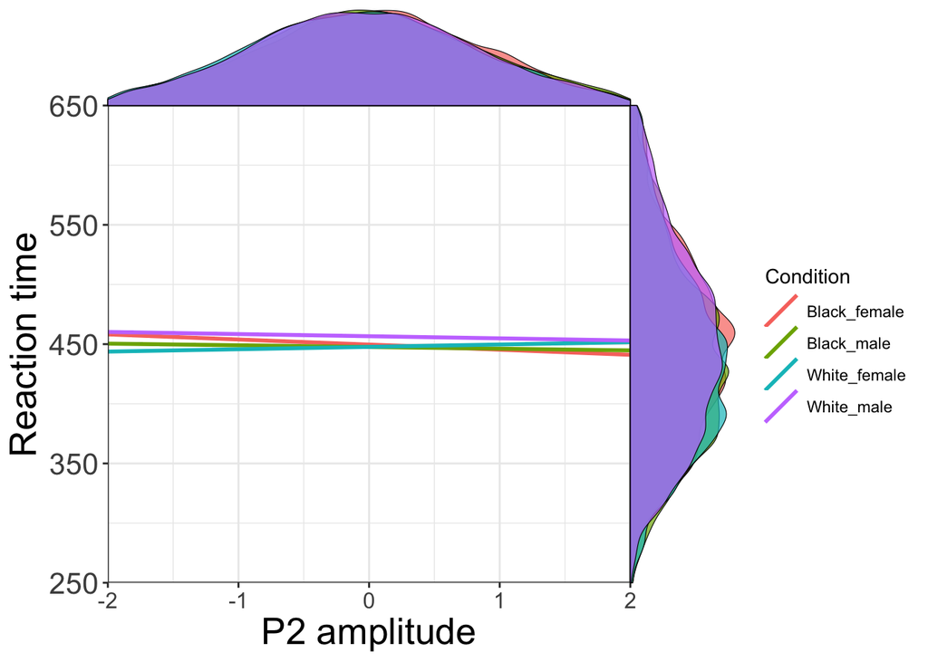

| Target_Race | Target_Gender | Intercept | Slope | Lower_95%CI | Upper_95%CI |
| --- | --- | --- | --- | --- | --- |
| Black | female | 450 | -4.29 | -5.65 | -2.93 |
| Black | male | 448 | -1.43 | -2.78 | -0.09 |
| White | female | 448 | 1.99 | 0.62 | 3.36 |
| White | male | 457 | -1.81 | -3.21 | -0.40 |

**Zoomed in:**

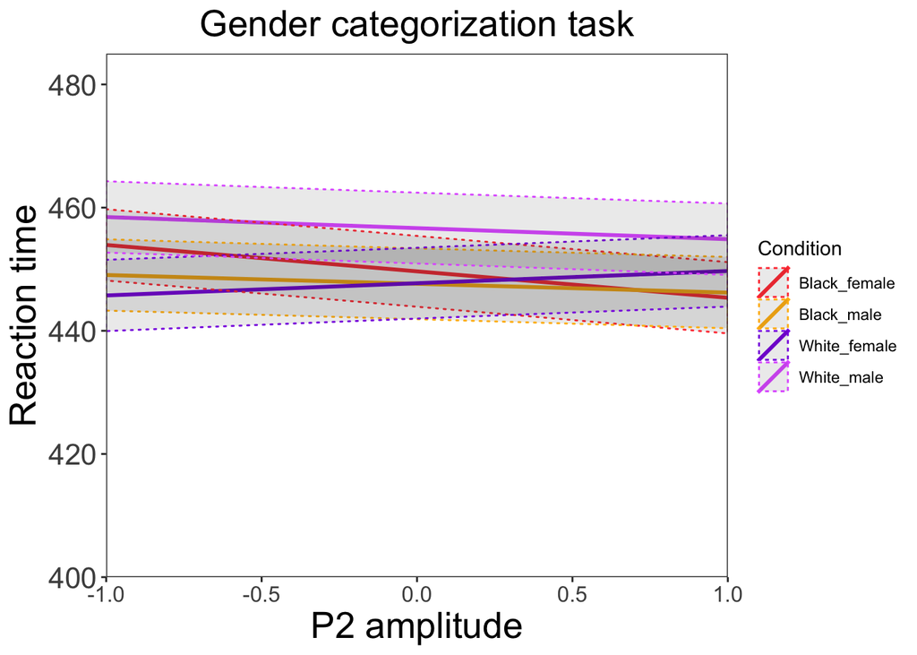

## 2. Examining between/within stimulus group effects

To examine the P2->RT relationship within stimulus type and between stimulus type, I created two new variables. P2.withinSub.betweenStim = mean P2 for each stimulus type, centered within sub P2.withinSub.withinStim = trial level P2, centered within each stim type, centered within sub P2.withinSub.withinStim.scale = trial level P2, centered within each stim type, centered within sub, standardized

### A. Race categorization task

```
## Linear mixed model fit by REML. t-tests use Satterthwaite's method [
## lmerModLmerTest]
## Formula:
## RT ~ P2.submean + P2.withinSub.withinStim + P2.withinSub.betweenStim +
##     (1 | Subject)
##    Data: filter(dat, Task == "RaceTask")
##
## REML criterion at convergence: 746788.3
##
## Scaled residuals:
##     Min      1Q  Median      3Q     Max
## -4.6527 -0.6745 -0.1137  0.5366  4.6382
##
## Random effects:
##  Groups   Name        Variance Std.Dev.
##  Subject  (Intercept) 1387     37.25
##  Residual             6739     82.09
## Number of obs: 64053, groups:  Subject, 65
##
## Fixed effects:
##                            Estimate Std. Error         df t value Pr(>|t|)
## (Intercept)               4.378e+02  4.680e+00  6.655e+01  93.556  < 2e-16
## P2.submean               -2.941e-02  2.728e-01  3.432e+04  -0.108 0.914125
## P2.withinSub.withinStim  -1.537e-01  4.155e-02  6.399e+04  -3.701 0.000215
## P2.withinSub.betweenStim -1.563e+00  2.436e-01  6.405e+04  -6.416 1.41e-10
##
## (Intercept)              ***
## P2.submean
## P2.withinSub.withinStim  ***
## P2.withinSub.betweenStim ***
## ---
## Signif. codes:  0 '***' 0.001 '**' 0.01 '*' 0.05 '.' 0.1 ' ' 1
##
## Correlation of Fixed Effects:
##              (Intr) P2.sbm P2.wthnSb.wS
## P2.submean   -0.142
## P2.wthnSb.wS  0.000  0.000
## P2.wthnSb.bS -0.010 -0.002  0.000
```

```
## Linear mixed model fit by REML. t-tests use Satterthwaite's method [
## lmerModLmerTest]
## Formula:
## RT ~ P2.submean + P2.withinSub.withinStim.scale + P2.withinSub.betweenStim +
##     (1 | Subject)
##    Data: filter(dat, Task == "RaceTask")
##
## REML criterion at convergence: 746784.2
##
## Scaled residuals:
##     Min      1Q  Median      3Q     Max
## -4.6527 -0.6745 -0.1137  0.5366  4.6382
##
## Random effects:
##  Groups   Name        Variance Std.Dev.
##  Subject  (Intercept) 1387     37.25
##  Residual             6739     82.09
## Number of obs: 64053, groups:  Subject, 65
##
## Fixed effects:
##                                 Estimate Std. Error         df t value
## (Intercept)                    4.378e+02  4.680e+00  6.655e+01  93.556
## P2.submean                    -2.941e-02  2.728e-01  3.432e+04  -0.108
## P2.withinSub.withinStim.scale -1.198e+00  3.236e-01  6.399e+04  -3.701
## P2.withinSub.betweenStim      -1.563e+00  2.436e-01  6.405e+04  -6.416
##                               Pr(>|t|)
## (Intercept)                    < 2e-16 ***
## P2.submean                    0.914125
## P2.withinSub.withinStim.scale 0.000215 ***
## P2.withinSub.betweenStim      1.41e-10 ***
## ---
## Signif. codes:  0 '***' 0.001 '**' 0.01 '*' 0.05 '.' 0.1 ' ' 1
##
## Correlation of Fixed Effects:
##             (Intr) P2.sbm P2.S.S.
## P2.submean  -0.142
## P2.wthnS.S.  0.000  0.000
## P2.wthnSb.S -0.010 -0.002  0.000
```

### B. Gender categorization task

```
## Linear mixed model fit by REML. t-tests use Satterthwaite's method [
## lmerModLmerTest]
## Formula:
## RT ~ P2.submean + P2.withinSub.withinStim + P2.withinSub.betweenStim +
##     (1 | Subject)
##    Data: filter(dat, Task == "GenTask")
##
## REML criterion at convergence: 718167.9
##
## Scaled residuals:
##     Min      1Q  Median      3Q     Max
## -3.3637 -0.6793 -0.1254  0.5143  4.5859
##
## Random effects:
##  Groups   Name        Variance Std.Dev.
##  Subject  (Intercept) 2086     45.67
##  Residual             7118     84.37
## Number of obs: 61308, groups:  Subject, 64
##
## Fixed effects:
##                            Estimate Std. Error         df t value Pr(>|t|)
## (Intercept)               4.504e+02  5.762e+00  6.481e+01  78.170  < 2e-16
## P2.submean               -7.951e-04  2.863e-01  4.255e+04  -0.003    0.998
## P2.withinSub.withinStim  -1.921e-01  4.385e-02  6.124e+04  -4.381 1.18e-05
## P2.withinSub.betweenStim  3.008e-01  2.586e-01  6.130e+04   1.163    0.245
##
## (Intercept)              ***
## P2.submean
## P2.withinSub.withinStim  ***
## P2.withinSub.betweenStim
## ---
## Signif. codes:  0 '***' 0.001 '**' 0.01 '*' 0.05 '.' 0.1 ' ' 1
##
## Correlation of Fixed Effects:
##              (Intr) P2.sbm P2.wthnSb.wS
## P2.submean   -0.121
## P2.wthnSb.wS  0.000  0.000
## P2.wthnSb.bS  0.009  0.002  0.000
```

```
## Linear mixed model fit by REML. t-tests use Satterthwaite's method [
## lmerModLmerTest]
## Formula:
## RT ~ P2.submean + P2.withinSub.withinStim.scale + P2.withinSub.betweenStim +
##     (1 | Subject)
##    Data: filter(dat, Task == "GenTask")
##
## REML criterion at convergence: 718163.8
##
## Scaled residuals:
##     Min      1Q  Median      3Q     Max
## -3.3637 -0.6793 -0.1254  0.5143  4.5859
##
## Random effects:
##  Groups   Name        Variance Std.Dev.
##  Subject  (Intercept) 2086     45.67
##  Residual             7118     84.37
## Number of obs: 61308, groups:  Subject, 64
##
## Fixed effects:
##                                 Estimate Std. Error         df t value
## (Intercept)                    4.504e+02  5.762e+00  6.481e+01  78.170
## P2.submean                    -7.951e-04  2.863e-01  4.255e+04  -0.003
## P2.withinSub.withinStim.scale -1.497e+00  3.416e-01  6.124e+04  -4.381
## P2.withinSub.betweenStim       3.008e-01  2.586e-01  6.130e+04   1.163
##                               Pr(>|t|)
## (Intercept)                    < 2e-16 ***
## P2.submean                       0.998
## P2.withinSub.withinStim.scale 1.18e-05 ***
## P2.withinSub.betweenStim         0.245
## ---
## Signif. codes:  0 '***' 0.001 '**' 0.01 '*' 0.05 '.' 0.1 ' ' 1
##
## Correlation of Fixed Effects:
##             (Intr) P2.sbm P2.S.S.
## P2.submean  -0.121
## P2.wthnS.S.  0.000  0.000
## P2.wthnSb.S  0.009  0.002  0.000
```